# The religious battleground in macroeconomic modeling

Charl Jooste

9/16/2021

Abstract

This short note suggests that the different modeling approaches used by policy makers are not that different in terms of producing outputs. We should pause before we critisize and engage with the content material, and ideologies, before making sharp judgments about what qualifies as an appropriate or good model.

# 1 My model is better than yours

It is very easy to criticize macroeconomic models. Often I feel like these criticisms are ad hoc. They smack like religious differences. The world is seen from a neoclassical lens, a Marxist sickle, an Austrian moment, a Keynesian impulse or any hybrid mutation. The defence and attack of these models have a religious undertone to it since a lot of what we can measure is noisy while many things remain unobservable. Our priors inform our views and typically our priors are based on our studies at university.

Modelers and economist try to follow a scientific methodology, which entails having a testable hypothesis vs. an alternative. So when it comes to asking which model is best, we should try and define our measure of interest. What is the definition of **the best**? It is very murky subject. For economists this might be grouped into the following:

- Mathematical beauty.
- Predicting some observable variable with highest precision.
- Illuminating our understanding of how the world works.

How do you test these things? Mathematical beauty is very subjective. Is it complexity systems or the ability to distill an idea into simple and intuitive equations. What matters here seems to be individual aesthetic preferences. How do you measure illumination? We clearly understand things differently. If I have a Marxist bias I will always favor models that make me understand Marxist economics better. Maybe you think it is about prediction then. We pretend to have objective tests. These tests may be broadly characterized as the accuracy of predictions or whether they can mimic something we observe in the data. Unfortunately the results of these tests remain obscure because **we cannot even measure main aggregate economic variables**. Macroeconomic data is constructed based on a set of assumptions (sample size, weights, statistical imputations etc.). So at best, accuracy of models depend on how well they explain constructed data (which by design is not free of noise).

No wonder economist get into such defensive fights about their modeling choices - because it is pretty much about emotions.

If you want economists to get into a boxing match then ask them about their views on modeling rational expectations. Are expectations backward looking or forward looking? Are people able to learn in a systematic manner (e.g.. perceived law of motion [Evans and Honkapohja](https://www.jstor.org/stable/3648625))? Are there constraints in cognitive abilities (e.g., bounded rationality [Gabaix](https://scholar.harvard.edu/files/xgabaix/files/behavioral_new_keynesian_model.pdf))? Are preferences fixed? Are there legitimate objective tests for these things ([Svendsen](https://www.ssb.no/a/publikasjoner/pdf/DP/dp_090.pdf),[Lovell](https://www.jstor.org/stable/1804130),[D’Haultfoeuille, Gaillac, Maurel](https://www.nber.org/system/files/working_papers/w25274/w25274.pdf),[Coibion, Gorodnichenko](https://www.jstor.org/stable/43821351)). People defend their views as if there is legitimate proof that one theory is better than another. These topics, however, are super interesting to study and they help us think about several possibilities of how the world works.

But, what all of this points to is a reminder of what the real purpose of modeling is and that we should remain humble about what they can produce. Models are imperfect, but stylized representations of reality. **They reflect the views of the modeler**, stitched together by a piece of code and then used to ask questions about policy and shocks. Models help us to articulate thoughts and to pin down logical arguments about policy.

That being said, some models are better at articulating thoughts in a coherent fashion than others, while other models are better at describing data (even noisy ones) than others. The quality of logic is based on the underlying assumptions of the model.

## 1.1 So what is the problem then?

The problem is hard. It is about policy and what actions to take when we simply do not know how the future will evolve.

Two important illustrations of this policy problem is fiscal policy and climate change impacts.

On fiscal policy there is a lot written. Many empirical papers find that fiscal stimulus is good and others find that it does not do much. My reading is that the results are ambiguous, but because of my training I am inclined to take the view that a smaller government is better than a larger one. If what I believe is true then large spending cannot be good for growth and development. If I am wrong then large spending is good for growth and development. So what policy should be exercised?

Climate change is also tricky. It is tricky because it is a known-unkown (maybe for some even an unkown-unknown). My view is that climate change is real and humans contribute to it. The consequences can be disastrous (in my estimation it is likely to be really bad). However, I do not know when the really bad things will happen? Why? Because I don’t have perfect data to extrapolate the consequences. Others believe that climate change is not man-made or will not be bad.

Now the model you choose matters for generating the results. The assumptions in those models matter for the sign and magnitude of shocks (follow the heated debates and controversies from [Tol](https://www.aeaweb.org/articles?id=10.1257/jep.23.2.29), [DICE model](https://www.pnas.org/content/114/7/1518), [Tipping points](https://www.nature.com/articles/d41586-019-03595-0) and [triggers](https://www.carbonbrief.org/explainer-nine-tipping-points-that-could-be-triggered-by-climate-change).

Some of these modeling frameworks are even similar, yet produce results that do not say the same things. From a modeling perspective these things are hard to sort out.

# 2 Many models, but the same thing

While it might sound like a contradiction to the previous statement, different models may produce very similar results (at least of the vanilla variety). This is because the underlying theory for them are similar, if not exactly the same.

There are mainly four types of macro models used by central banks or ministries of planning or finance (Post-Keynesian and dynamic nonlinear systems models are also used, but tend to be less popular):

- Macrostructural models (MS)
- Dynamic stochastic general equilibrium models (DSGE)
- Computable general equilibrium models (CGE)
- Empirically driven models (e.g., VARS)

A lot of fighting (and hence a lot of writing) is about the superiority or inferiority of MS vs. DSGE models. A very nice paper by [Storm](https://www.tandfonline.com/doi/full/10.1080/08911916.2021.1929582) discusses several fallacies of DSGE models (I am a fan of both DSGE and MS models).

In fact I don’t think there is much that separates the first three of these models. A neoclassical system forms the core of them. They entail a utility maximizing household, a cost-minimizing firm and several clearing conditions (e.g., market-clearing). In the long-run there exists a steady state. In the steady state all real variables grow at the same rate (typically equal to productivity growth adjusted for the labor income share plus population growth). The short run (more MS and DSGE) entails adjustment costs (for prices, wages and investments), with the underlying theory being very similar (polynomial adjustment costs related to union pressure, sticky prices or investment costs). The return to some equilibrium in the MS model is determined by empirically estimated error-correction parameters and supported by add-factors and short-run coefficients, while the return to equilibrium in the DSGE model is determined by the difference equations. Adjustment in these models also entails the modeling of expectations. Here the modeler needs to decide whether her firm or consumer has foresight and if they do, then whether they can act on that knowledge. Foresight does not imply a change in behavior, especially when credit constraints play a role. Foresight is also imperfect given that people have attention biases. Perhaps foresight can best be described via the process of learning (which by nature is imperfect). Anyway, the foresight modeling decision is tricky because it is hard to empirically establish. It does, however, seem to make sense to add additional blocks to capture important economic elements - but if they are in all models then the different results are derived from parameter assumptions, structural breaks and outlier corrections (see nice comparison of DSGE model by [Yagihashi](https://www.mof.go.jp/pri/research/discussion_paper/ron333.pdf))

If you are not convinced about the similarity between MS, DSGE and CGE models, let’s turn to an example. Let’s model the household consumption decision. We illustrate the similarity between the vanilla setup and argue that additional blocks, if modeled in a similar way, should produce also similar results (e.g., adding climate or fiscal policy). The point I want to emphasize is that discussing data and parameter assumptions should take a more central role when analyzing the results and that the discussion between DSGE, MS and CGE models are really at the margin (at least for the long-run). In fact there seems to be a middle-ground (see interesting discussions and comparisons by [Wickens](https://voxeu.org/article/theory-versus-statistical-fit-macroeconomic-modelling), [Korinek](https://www.ineteconomics.org/uploads/downloads/Korinek-DSGE-Macro-Essay.pdf))

## 2.1 Comparing equations across models: The consumption equation

We start with an objective function. In this case the representative household wishes to maximize her utility (whatever that is). In most classic and modern economics textbooks utility is increasing in consumption $(C)$. In the text book model household enjoy leisure time $(L)$ and not so much work $(N)$ (obviously some of us like to work). A standard equation to represent the desire to consume and the utility from leisure is:

$$U(C,N) = \text{max} \sum_{t} \beta^{t} \left(\frac{C_{t}^{1-\sigma}}{1-\sigma}+\frac{(1-N_t)^{1-\psi}}{1-\psi}\right)$$

The household cannot consume infinite amounts of goods and services without earning an income or being endowed with something. In these models we have to write a budget constraint. In a sequential markets economy it will look something like:

$$P_t C_t + P_t(K_{t+1}-(1-\delta)K_t)+B_t \leq (1+r_{t-1})B_{t-1}+P_tR_t K_t+P_tW_tN_t$$

The budget constraint shows that nominal consumption $(P_t C_t)$ plus nominal investment $(P_t C_t= P_t(K_{t+1}-(1-\delta)K_t))$ plus nominal loans $(B_t)$ cannot exceed the nominal loan repayment $((1+r_{t-1})B_{t-1})$, plus nominal labor earning $P_tW_tN_t)$ and capital rents $(P_tR_t K_t)$ for all time period (assume it is yearly $(t)$. This is a standard optimization problem that all students of economics will encounter.

In this model there are three parameters of interest: - The discount rate $\beta$. - The Arrow-Pratt measure of relative risk aversion $\sigma$ - The inverse Frisch elasticity of substitution $\psi$.

Solving this model can be done in several ways, the easiest by setting up a Lagrangian. The solution for the household consumption choice is called the intertemporal consumption Euler equation and is written as:

$$1=\beta R_t E_t \left(\left(\frac{C_{t+1}}{C_t}\right)^{-\sigma} \frac{P_t}{P_{t+1}} \right)$$

Economists often linearize this equation, assuming that a steady state can be found (an analytical solution is available for the standard real business cycle model):[^1]

$$c_t = c_{t+1}-\frac{1}{\sigma}(r_t-E_t \pi_{t+1})$$

This equation has been critized a lot (see [Carroll](https://www.nber.org/papers/w6298)). One of the interesting conclusions about it is that consumption choices are smoothed and any variations in consumption is only due to real interest rate changes and not due to current income changes.

The standard DSGE solution for consumption is that any gap (in this case consumption deviation around the steady state) disappears (i.e., is zero). Steady state consumption (which is a function of the parameters in the system) grows in line with total factor productivity plus population growth (assuming there is a stochastic trend for TFP and that population is included). TFP in this model is mainly an exogenous process (see [Sims example](https://www3.nd.edu/~esims1/dynare_examples.pdf))

To make the consumption equation slightly more realistic (realism I know, is subjective) one can add liquidity constrained households (consumption is equal to labor income) and then weight consumption choices where $\lambda$ is the weight of consumption of of current income and $(1-\lambda)$ is consumption from permanent income $(c_t = \lambda c_t^{CC} + (1-\lambda)c_t^{O)})$. According to [Campbell and Mankiw](https://www.nber.org/system/files/chapters/c10965/c10965.pdf), our final equation can be written as ([see Gali et al.](https://www.nber.org/system/files/working_papers/w11578/w11578.pdf)):

$$c_t = \Theta_n n_t -\sigma \sum_{k=0}^{\infty} E_t (r_{t+k}-\pi_{t+k+1})$$

Note that $\Theta_n$ and $\sigma$ are reduced-form parameters that are a function of the risk aversion parameter, markups and constrained consumption share.

This consumption equation now has a place for current consumption, whereas the standard Euler equation has none.[^2]

The consumption equation in MS models can take many forms. Good examples is the standard consumption equation for [US FED](https://www.federalreserve.gov/pubs/feds/1996/199642/199642pap.pdf) and the [World Bank’s MFMod](https://openknowledge.worldbank.org/handle/10986/32217)). This equation can be written as:

$$\Delta ln(C_t) = \alpha + \theta [ln(C_{t-1}-ln(C_{t-1}^*)]+\beta_1 \Delta ln(C_t^*)-\beta_2 ln(r_t-\pi_{t+1})+\varepsilon_t^C$$

where $C_t^*$ is a weighted average of current income, wealth and transfers and represents the long-run solution to the equation. The long-run growth rate for consumption here will also depend on productivity growth. Assume a two-period problem solution for consumption is $C_2 = C_1 \beta (1+r)^\sigma$ and the resource constraint $C_1+\frac{C_2}{1+r} = W_1 N_1+\frac{W_2 N_2}{1+r}$. Plug the solution into the constraint and after some algebra you obtain $C_1 = \frac{W_1 N_1+\frac{W_2 N_2}{1+r}}{1+\beta (1+r)^\sigma} = \kappa W_1 N_1(1+\frac{\frac{W_2 N_2}{W_1 N_1}}{1+r})$. Note that $\kappa = \frac{1}{1+\beta (1+r)^\sigma}$ and $\frac{W_2 N_2}{W_1 N_1} = 1+\Delta ln(Y_t^*)$ . The long-run consumption solution can thus be approximated as:

$$ln(C_t)=ln(\kappa)+ln(W_1 N_1)+\Delta ln(Y_t^*)-r_t$$

In MS models, long-run output grows in line with TFP growth (adjusted for the output elasticity of labor) and population growth $(\Delta ln(Y_t^*) = \frac{\Delta ln(A_t)}{\gamma}+\Delta ln(POP_t)$

## 2.2 Concepts that are similar across the models:

1. Both DSGE and MS models have a balanced growth path, which is pinned down by productivity growth and population growth (in most policy models they are exogenous).
2. Given that we have a balanced growth path, the big ratios (Kaldor facts) will be maintained.
3. Both equations look very similar in the sense that real interest rates affect household behavior and that permanent income determines the long-run.
4. While this version of the MS model does not include a forward looking term, it can be incorporated. A solution mechanism exists (e.g., stacked time solving).
5. Both have a long and short run component where the dynamics in the MS model is dealt with the error-correction parameter $\theta$ and the short-run elasticities.

## 2.3 A simple modeling demonstration:

In this demonstration we will use the modeling assumptions for the DSGE and MS models and simulate their paths. We have to close the model. As is standard in the DSGE literature, a minimum representative log-linearized model consists of an IS-curve, a Phillips curve and a Taylor rule. We are assuming a closed-economy setting for this illustration and abstract from investment and government choices (this is not necessary for the illustration).

**The DSGE system of equations**

$$x_t = x_{t+1}-\frac{1}{\sigma}(r_t-E_t \pi_{t+1})$$

$$\pi_{t} = \beta \pi_{t+1}+\gamma x_t$$

$$r_{t} = 1.5 \pi_{t}+v_t$$

In this system all variables are expressed as log-deviations from steady state. The output gap is equal to consumption divided by potential $x_t = (C_t/C_t^*-1)$, the inflation gap is equal to inflation less target inflation $\pi_{t} = \Delta ln(P_t)-\pi^*$ and the interest rate gap is equal to actual interest less the natural rate $r_t = R_t-R^*_t$. For the model to solve we need to provide values for the steady state variables. Potential consumption is equal to a growth of three percent while inflation target and the natural rate is equal to the last historical valued.

Note that this model fits the data very poorly (using South African data). We thus use some calibrations from [Jooste et al.](https://www.sciencedirect.com/science/article/pii/S0264999313000618) We calibrate $\gamma = \frac{(1-\zeta)(1-\beta\zeta)}{\zeta} = 0.095$ where $\beta = 0.99$

**The MS system of equations**

Instead of the output gap, we use the standard ECM formulation above, while retaining the Taylor rule and Phillips curve equation:

We use three variations of the ECM equation:

1. everything is backward looking (including the Phillips curve).
2. Polynomial adjustment in the steady state and expected inflation. In this case we have $\beta_{11} \Delta ln(C_{t-1}^*)+\beta_{12} \Delta ln(C_{t}^*)+\beta_{13} \Delta ln(C_{t+1}^*)$.
3. Only expected forward-looking inflation. The ECM is calibrated to be very large.

Figure 1 compares the output gaps derived from the DSGE and MS models for [1]. The output gap in the DSGE model reacts very sharply to the interest rate shock (there is no backwards smoothing in the IS curve). The MS model produces a slight delay in consumption response due to the backward looking nature of the model. However, after 1 period the dynamics of the output gaps are very similar and the return to steady state the same. The main difference in the system is the inflation response, which is much larger in the DSGE model. Several revisions to DSGE models include indexing the Phillips curve also to past inflation as a means of smoothing the output.

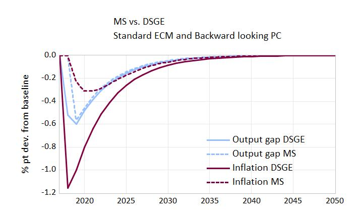

Backward looking

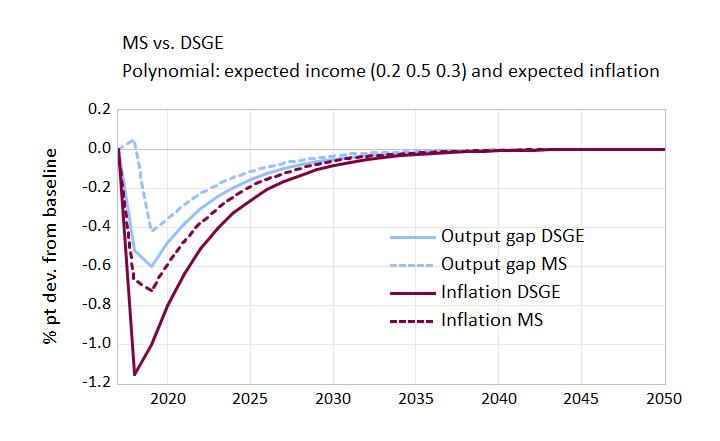

Polynomial adjustment

[figure not shown]

# 3 What to take from this note

Let’s summarize the key take-away points from this short note:

1. **All** models can be critiqued.
2. The distinction between DSGE and MS models are not that big in the short-run and the distinction even less clear in the long-run.
3. The distinctions are unclear because the theoretical basis for the models are practically the same.
4. MS models can incorporate **deep** parameters using proper identification methods (e.g., instrumental variable methods or systems estimation). However, the reduced form parameters may also be stable in which case they are policy invariant. For a nice discussion about the Lucas critique and how it is dealt within MS models see [Hendry](https://www.jstor.org/stable/20076341); [Farmer](https://www.tandfonline.com/doi/abs/10.1080/07474939208800239?journalCode=lecr20); [Ericsson and Irons](https://link.springer.com/chapter/10.1007/978-94-011-0669-6_8).
5. Adding additional details to the models (such as climate) should also produce similar results if parameter assumptions and expectations formations are the same.

Finally there is a practical matter to consider. It takes considerable effort to build models (starting from theory, to estimation to testing). However, people tend to be more comfortable if the model can describe data (yes most data are messy). In this case MS models tend to be more realistic since it requires less assumptions about detrending correctly (which filter is the best to describe the unobservable world?).

The takeaway is that if you want to criticize models then you should first start by understanding the differences between them and whether those differences can be measured and whether they are realistically making a big difference to your results.

[^1]: Lower case letters denote log deviations from steady state. The bar notation is the steady state. In steady state $\beta \bar{R} = 1$
[^2]: The empirical equation in [Campbell and Mankiw](https://www.nber.org/system/files/chapters/c10965/c10965.pdf) is written as: $\Delta c_t = \alpha + \lambda \Delta y_t + (1-\lambda)\sigma (r_t-\pi_t)$